# Vector Data HW: Comparing Dogwood Neighborhoods

Do Urban and Suburban dogwoods actually have different surrounding landscapes, or does their classification mostly reflect where someone drew a latitude boundary?

Author

Dez Waag

Published

October 29, 2026

Abstract

Land cover within 250 m of dogwood trees in the Richmond area was compared across Native, Suburban, and Urban habitats using the Richmond Dogwoods dataset and the 2021 National Land Cover Database. Urban neighborhoods had a higher average proportion of developed land than Suburban neighborhoods, while Native neighborhoods were predominantly forested; however, substantial overlap among individual cultivated trees suggests that the urban–suburban boundary does not sharply separate distinct landscapes.

## Introduction

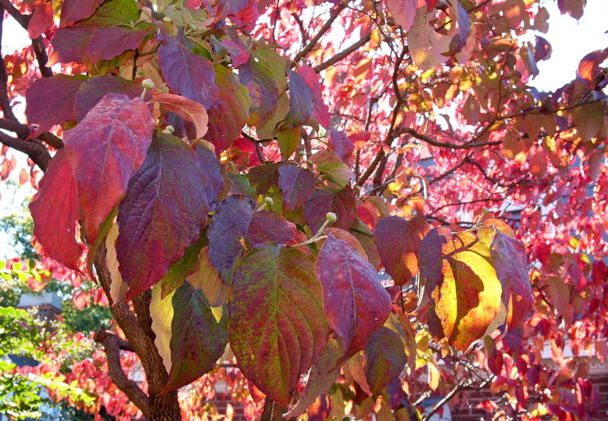

The fabulous fall foliage of *Benthamidia florida* (Flowering Dogwood). Photo © Mary Free. Master Gardeners of Northern Virginia

##### Flowering dogwood (*Benthamidia florida*), Virginia’s state tree, is a popular choice for landscaping because of its showy spring blooms and colorful fall foliage. Its presence in both woodlands and planted landscapes makes it a useful species for exploring how surrounding land cover varies across habitats. This analysis compares the neighborhoods around Native, Suburban, and Urban dogwoods in the Richmond area to examine whether the urban–suburban distinction reflects a clear difference in the landscapes where these trees grow.

## Methods

### Data

The Richmond Dogwoods dataset was used from the course data repository, which contains locations and habitat classifications for dogwood trees from Richmond south to Pocahontas State Park. After importing the CSV into R, `st_as_sf()` was used to convert the Longitude and Latitude columns into spatial points, identifying their original coordinate system as WGS84. The coordinate columns were kept so that Latitude could also be used in the north–south plot. Finally, `st_transform()` was used to project the points into UTM Zone 17N, which uses meters and allows a 250 m neighborhood to be created around each tree.

```r
library( sf )
library( tidyverse )
library( knitr )
library( kableExtra )

url <- "https://dyerlabteaching.github.io/CourseData/Spatial/Richmond_Dogwoods.csv"

read_csv(url) |>
  st_as_sf(
    coords = c("Longitude", "Latitude"),
    crs = 4326,
    remove = FALSE
  ) |>
  st_transform(crs = 32617) -> trees

nrow(trees)
```

```
[1] 58
```

```r
trees |>
  st_drop_geometry() |>
  count(Habitat)
```

```
# A tibble: 3 × 2
  Habitat      n
  <chr>    <int>
1 Native      26
2 Suburban    13
3 Urban       19
```

```r
st_crs(trees)$units_gdal
```

```
[1] "metre"
```

### Analysis

A circular neighborhood extending 250 m around each dogwood tree was created using `st_buffer()`. The course’s `get_landcover()` function was used to calculate the proportion of each neighborhood occupied by seven land-cover categories from the 2021 National Land Cover Database. These measurements were then grouped by `Habitat` and land-cover category, and mean proportions were calculated to compare Native, Suburban, and Urban neighborhoods. Developed-land proportions were also plotted against latitude for individual cultivated trees to examine how much Urban and Suburban neighborhoods overlap and whether there is a clear change at the habitat boundary.

```r
source("https://dyerlabteaching.github.io/Vector-Data/get_landcover.R")

trees |>
  st_buffer(dist = 250) -> nbhd

nbhd |>
  get_landcover() -> lc

lc |>
  group_by(Habitat, Category) |>
  summarize(
    Proportion = mean(Proportion),
    .groups = "drop"
  ) -> habitat_lc

nrow(nbhd)
```

```
[1] 58
```

```r
nrow(lc)
```

```
[1] 406
```

```r
habitat_lc
```

```
# A tibble: 21 × 3
   Habitat  Category    Proportion
   <chr>    <chr>            <dbl>
 1 Native   Agriculture    0.00578
 2 Native   Barren         0.00384
 3 Native   Developed      0.0511
 4 Native   Forest         0.835
 5 Native   Shrub/Grass    0.00628
 6 Native   Water          0.0118
 7 Native   Wetland        0.0862
 8 Suburban Agriculture    0.0141
 9 Suburban Barren         0.00318
10 Suburban Developed      0.738
# ℹ 11 more rows
```

The following code prepares tree counts and selected land-cover percentages for use in the Results text, allowing reported values to update automatically when the document is rendered.

```r
n_native   <- sum(trees$Habitat == "Native")
n_suburban <- sum(trees$Habitat == "Suburban")
n_urban    <- sum(trees$Habitat == "Urban")

urban_dev <- habitat_lc |>
  filter(Habitat == "Urban", Category == "Developed") |>
  pull(Proportion)

suburban_dev <- habitat_lc |>
  filter(Habitat == "Suburban", Category == "Developed") |>
  pull(Proportion)

native_forest <- habitat_lc |>
  filter(Habitat == "Native", Category == "Forest") |>
  pull(Proportion)

dev_gap <- format(
  round(100 * (urban_dev - suburban_dev), 1),
  nsmall = 1 )

urban_dev <- format(
  round(100 * urban_dev, 1),
  nsmall = 1 )

suburban_dev <- format(
  round(100 * suburban_dev, 1),
  nsmall = 1 )

native_forest <- format(
  round(100 * native_forest, 1),
  nsmall = 1 )
```

## Results

The analysis included 26 Native, 13 Suburban, and 19 Urban dogwood trees. Their neighborhoods extend across the Richmond area, with Native trees located in Pocahontas State Park and cultivated trees distributed farther north (Figure 1). The interactive map below allows individual neighborhoods to be explored against satellite imagery; selecting a polygon displays its habitat classification.

```r
library(leaflet)

nbhd_web <- nbhd |>
  st_transform(crs = 4326)

habitat_colors <- colorFactor(
  palette = c("forestgreen", "goldenrod", "steelblue"),
  domain = c("Native", "Suburban", "Urban") )

leaflet(nbhd_web) |>
    addProviderTiles(providers$Esri.WorldImagery) |>
  addPolygons(
    fillColor = ~habitat_colors(Habitat),
    fillOpacity = 0.9,
    color = ~habitat_colors(Habitat),
    weight = 2,
    opacity = 1,
    popup = ~paste0(
      "<b>Habitat:</b> ", Habitat,
      "<br><b>Neighborhood radius:</b> 250 m" ),
    highlightOptions = highlightOptions(
      weight = 3,
      bringToFront = TRUE ) ) |>
  addLegend(
    position = "bottomright",
    pal = habitat_colors,
    values = ~Habitat,
    title = "Habitat" ) |>
  addScaleBar(position = "bottomleft")
```

[interactive chart not shown]

The same neighborhoods are shown without background imagery in Figure 1, making their spatial distribution and overlap easier to distinguish. Colors are kept consistent throughout the maps and charts to support comparison among habitats.

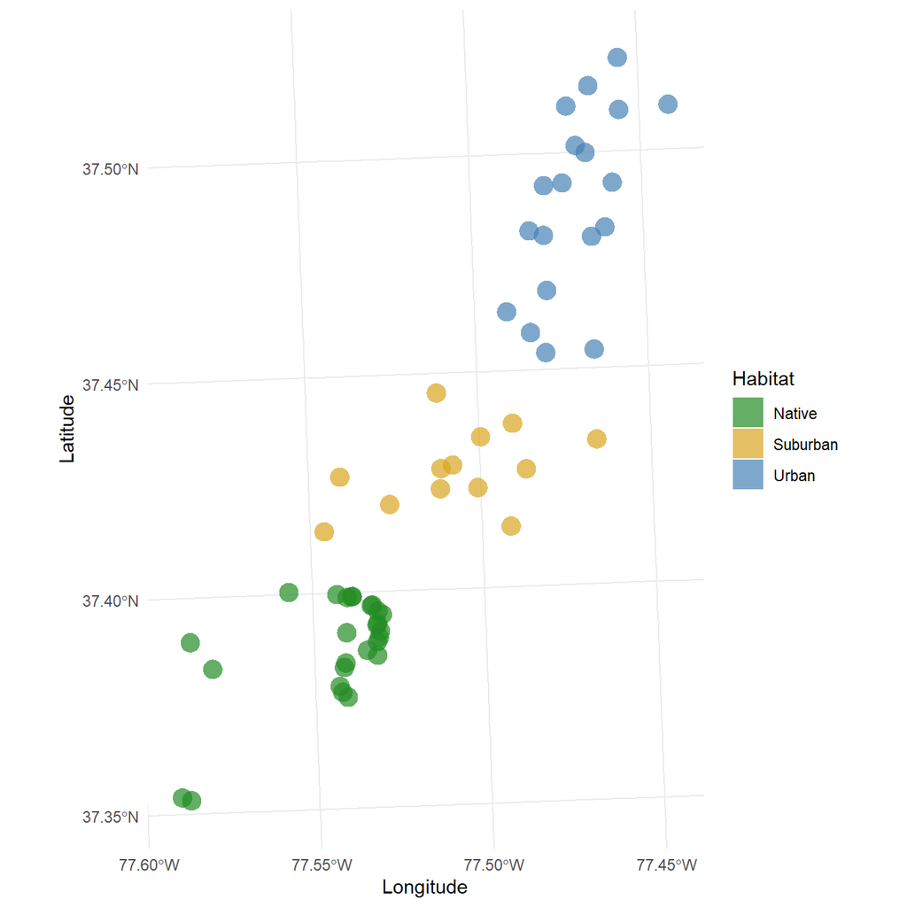

Figure 1: Neighborhoods extending 250 m around dogwood trees in the Richmond area, colored by habitat.

```r
ggplot(nbhd) +
  geom_sf(
    aes(fill = Habitat),
    color = NA,
    alpha = 0.7 ) +
  scale_fill_manual(
    values = c(
      "Native" = "forestgreen",
      "Suburban" = "goldenrod",
      "Urban" = "steelblue" ) ) +
  labs(
    x = "Longitude",
    y = "Latitude",
    fill = "Habitat" ) +
  theme_minimal()
```

Land-cover proportions were averaged across the individual tree neighborhoods within each habitat (Table 1). These values describe the average surroundings of a tree in each group, rather than the land cover of the entire region occupied by that habitat.

```r
habitat_lc |>
  pivot_wider(
    names_from = Habitat,
    values_from = Proportion ) |>
  select(Category, Native, Suburban, Urban) |>
  kable(
    digits = 3,
    col.names = c("Land-cover category", "Native", "Suburban", "Urban") ) |>
  kable_paper("striped", full_width = FALSE)
```

Table 1: Average proportion of each land-cover category within 250 m of dogwood trees, by habitat.

| Land-cover category | Native | Suburban | Urban |
| --- | --- | --- | --- |
| Agriculture | 0.006 | 0.014 | 0.002 |
| Barren | 0.004 | 0.003 | 0.000 |
| Developed | 0.051 | 0.738 | 0.906 |
| Forest | 0.835 | 0.154 | 0.066 |
| Shrub/Grass | 0.006 | 0.004 | 0.002 |
| Water | 0.012 | 0.001 | 0.007 |
| Wetland | 0.086 | 0.086 | 0.017 |

Urban neighborhoods averaged 90.6% developed land, compared with 73.8% for Suburban neighborhoods, a difference of 16.8 percentage points (Table 1). Native neighborhoods were predominantly forest, averaging 83.5% forest cover. These differences are displayed in Figure 2, which also shows that Suburban neighborhoods contained more forest and wetland cover than Urban neighborhoods.

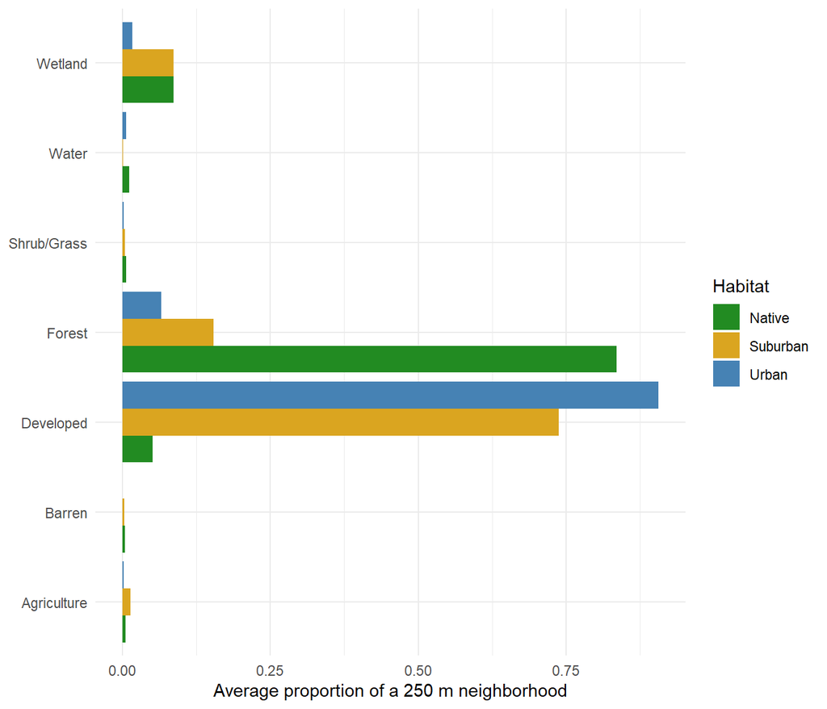

Figure 2: Average land-cover proportions within 250 m of dogwood trees, by habitat.

```r
ggplot(
  habitat_lc,
  aes(x = Category, y = Proportion, fill = Habitat) ) +
  geom_col(position = "dodge") +
  coord_flip() +
  scale_fill_manual(
    values = c(
      "Native" = "forestgreen",
      "Suburban" = "goldenrod",
      "Urban" = "steelblue" ) ) +
  labs(
    x = NULL,
    y = "Average proportion of a 250 m neighborhood",
    fill = "Habitat" ) +
  theme_minimal()
```

Although the habitat averages differ, they do not show how much variation occurs among individual trees. Developed-land proportions were therefore plotted against latitude for each cultivated tree (Figure 3). The dashed line marks the latitude boundary used to separate Suburban and Urban trees, allowing the individual neighborhoods on either side to be compared.

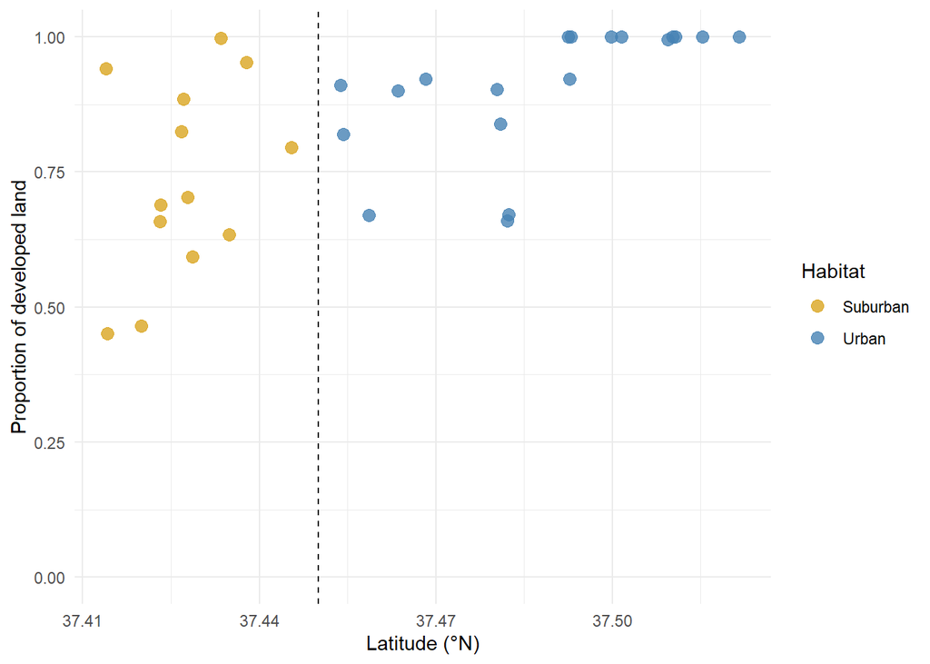

Figure 3: Developed land-cover proportion within 250 m of each cultivated dogwood tree, by latitude. The dashed line marks the habitat boundary at 37.45°N.

```r
lc |>
  filter(
    Mother == "Cultivar",
    Category == "Developed" ) |>
  ggplot(aes(
    x = Latitude,
    y = Proportion,
    color = Habitat )) +
  geom_point(size = 3, alpha = 0.8) +
  geom_vline(
    xintercept = 37.45,
    linetype = "dashed" ) +
  scale_color_manual(
    values = c(
      "Suburban" = "goldenrod",
      "Urban" = "steelblue" ) ) +
  scale_y_continuous(limits = c(0, 1)) +
  labs(
    x = "Latitude (°N)",
    y = "Proportion of developed land",
    color = "Habitat" ) +
  theme_minimal()
```

### Interpretation

The Urban and Suburban classifications reflect a difference in average surrounding land cover, but the division is not absolute. Urban neighborhoods had a higher average proportion of developed land, while Suburban neighborhoods contained more forest and wetland cover (Table 1). However, individual neighborhoods overlapped substantially in their developed-land proportions: some Suburban neighborhoods were nearly entirely developed, while some Urban neighborhoods had noticeably less development (Figure 3). The plot does not show a sharp change at the habitat boundary. Together, these results suggest that the labels describe a broad landscape difference but do not cleanly separate two distinct types of neighborhood.

## Conclusion

The comparison of 26 Native, 13 Suburban, and 19 Urban dogwood trees showed differences in their surrounding land cover. Native neighborhoods averaged 83.5% forest cover, while Urban and Suburban neighborhoods averaged 90.6% and 73.8% developed land, respectively (Table 1; Figure 2). Urban neighborhoods therefore had 16.8 percentage points more developed land on average than Suburban neighborhoods. However, the individual trees showed substantial overlap in developed-land proportions, with no clear jump at the latitude boundary (Figure 3). These findings suggest that the Urban and Suburban classifications capture an average landscape difference, but do not represent a sharp separation between two distinct environments.

### Questions

What units is the `250` in `st_buffer( dist = 250 )`, and how can you tell from the `trees` object? Why did we reproject into UTM first rather than buffering the points in their original longitude/latitude (`EPSG:4326`)?

- The value 250 represents meters, which is confirmed by `st_crs(trees)$units_gdal` returning `"metre"`. Reprojecting into UTM Zone 17N provides a local coordinate system with linear units, allowing the neighborhoods to be constructed using a straightforward planar distance of 250 m rather than working directly with longitude and latitude in degrees.

Your table *averages* the proportions across each tree’s neighborhood. If you instead unioned all the neighborhoods in a habitat into a single polygon and got the land cover of that, how could the answer differ, and why?

- Averaging the neighborhood proportions gives each tree equal weight, while land shared by overlapping neighborhoods contributes to more than one tree’s measurement. Unioning the neighborhoods would count each overlapping area only once, so the resulting proportions could increase or decrease depending on which land-cover categories occur in those shared areas.